# Geographic Harmonization Guide

Author

Manu Alcalá Kovalski

Published

November 25, 2024

```r
library(tidyverse)
library(here)
library(assertthat)
```

## Overview

This document includes the number of geographies in each year, justifications for decisions, and documentations of important changes to geographies. In particular, it addresses the following questions:

- What geographies are in our final data? How do they change over time?
- What are geographic crosswalks and when/how do I use them?
- What are all the geographic crosswalk in this project?
- Are the geographies in our final data aligned with our population files?

## What geographies are in our data? How do they change over time?

We report our final data for counties and places.

**Note**

Each year some new entities come into existence and other entities are dissolved. This may be the result of new incorporations or statistical delineations, the redrawing or splitting of administrative areas, disincorporations, mergers and consolidations, and other types of changes.

Check out the Census’s comphrensive [guide](https://www.census.gov/programs-surveys/geography/technical-documentation/county-changes.2010.html#list-tab-957819518) to all the changes to US census geographies to learn more.

### Counties

We have:

- 3,142 counties for 2014-2019
- 3,143 for 2020-2021
- 3,144 counties for 2022-2023

```r
county_data <- read_csv(here("geographic-crosswalks", "data", "county-populations.csv"))

county_data |>
  count(year)
```

```
# A tibble: 10 × 2
    year     n
   <dbl> <int>
 1  2014  3142
 2  2015  3142
 3  2016  3142
 4  2017  3142
 5  2018  3142
 6  2019  3142
 7  2020  3143
 8  2021  3143
 9  2022  3144
10  2023  3144
```

The average number of counties per state is 62, but the number varies from three in Delaware to 254 in Texas.

To understand the changes in our number of counties over time, there are **two key changes** to note:

#### Connecticut Planning Regions

The number of US counties increased in 2022 **due to a new county-equivalent map for Connecticut, which better reflected the state’s governance system**. The new map divided Connecticut into nine counties, instead of the previous eight.

Connecticut’s historical eight counties stopped serving as functioning governmental or administrative units in 1960. Currently, Connecticut has nine [Regional Councils of Government](https://portal.ct.gov/OPM/IGPP/ORG/Planning-Regions/Planning-Regions---Overview) (COG) that carry out regional planning and service delivery activities similar to those performed by county-level governments in other states. Planning regions are administrative entities that have have the same boundaries as the state’s COGs.

See the map below for the planning region boundaries, the towns within each planning region, and historical county boundaries (delineated by thick white borders)

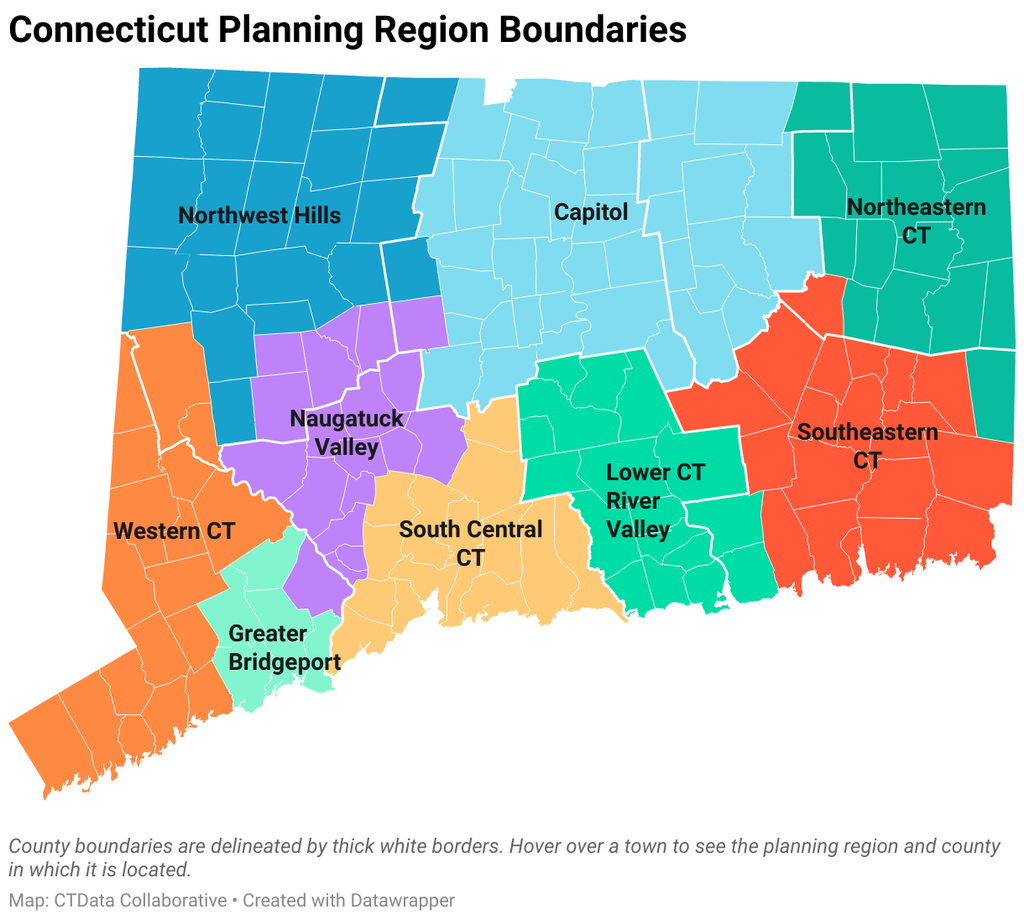

**Note**

County-equivalent planning regions will simply be referred to as “counties” in Census Bureau data products, although the geographic units will be labeled with the names of the planning regions instead of counties.

Due to data quality concerns with crosswalking from the old historical counties to planning regions, we we will keep using **Connecticut counties for 2014-2021** data and **switch to planning regions for data after and including 2022**. In particular, these concerns arise from the fact that the old counties are **not nested** within the new planning regions. Since tract or block-group level data isn’t available for most metrics, we can’t use a narrower geography to remediate this problem. This is particularly consequential for **non-count** variables. For more information, see [Geographic Crosswalks at Urban](https://ui-research.github.io/code-library/crosswalk-guide/geographic-crosswalks-at-urban.html#what-are-geographic-crosswalks).

#### Summary

In summary, we have

- 3,142 counties for 2014-2019
- 3,143 for 2020-2021 (**due to the Alaska county split, which adds one county)**
- 3,144 counties for 2022-2023 **(due to the incorporation of 9 CT planning regions and removal of eigh CT counties)**

**Check:** Do we have the same number of counties for each year? Or any dropping in and out?

```r
# Find unique places for each year
counties_per_year <- county_data %>%
  mutate(geoid = paste0(state, county), .after = "year") |>
  group_by(year) %>%
  summarize(counties = list(unique(geoid))) %>%
  arrange(year)

# Compare places between consecutive years
counties_comparison <- counties_per_year %>%
  mutate(
    dropped = ifelse(year > min(year),
      map2(counties, lag(counties), ~ setdiff(.y, .x)),
      NA
    ),
    new = ifelse(year > min(year),
      map2(counties, lag(counties), ~ setdiff(.x, .y)),
      NA
    )
  )

number_of_counties_changed <-
  counties_comparison |>
  # Remove first year of our data since by definition there can't be changes
  # from this period
  filter(year != 2014) |>
  mutate(
    counties = map_int(counties, length),
    dropped = map_int(dropped, length),
    new = map_int(new, length)
  )

number_of_counties_changed
```

```
# A tibble: 9 × 4
   year counties dropped   new
  <dbl>    <int>   <int> <int>
1  2015     3142       0     0
2  2016     3142       0     0
3  2017     3142       0     0
4  2018     3142       0     0
5  2019     3142       0     0
6  2020     3143       1     2
7  2021     3143       0     0
8  2022     3144       8     9
9  2023     3144       0     0
```

**Check:** Only one county 2020 is dropped from our data in 2020 (Valdez-Cordova)

```r
assert_that(
  number_of_counties_changed %>%
    filter(year == 2020) %>%
    pull(dropped) == 1
)
```

```
[1] TRUE
```

**Check:** 9 counties are added in 2022 (CT planning regions) and 8 counties are dropped (old CT counties)

```r
assert_that(
  number_of_counties_changed %>%
    filter(year == 2022) %>%
    pull(new) == 9
)
```

```
[1] TRUE
```

```r
assert_that(
  all(
    number_of_counties_changed %>%
      filter(year == 2022) %>%
      pull(dropped) == 8
  )
)
```

```
[1] TRUE
```

**Check:** Besides the counties removed and added in 2020 and 2022, there are no other dropped or added counties

```r
assert_that(
  all(
    number_of_counties_changed %>%
      filter(!(year %in% c(2020, 2022))) %>%
      pull(dropped) == 0
  )
)
```

```
[1] TRUE
```

```r
assert_that(
  all(
    number_of_counties_changed %>%
      filter(!(year %in% c(2020, 2022))) %>%
      pull(new) == 0
  )
)
```

```
[1] TRUE
```

### Places

Our final data contains incorporated places with populations greater than 75,000 in 2020.

The number of places in our data is

- 485 for 2015-2017
- 486 from 2018-2023

```r
places_data <- read_csv(here::here("geographic-crosswalks/data/place-populations.csv"))

number_of_years <- length(unique(places_data$year))

places_data |>
  group_by(year) |>
  distinct(state, place) |>
  count()
```

```
# A tibble: 9 × 2
# Groups:   year [9]
   year     n
  <dbl> <int>
1  2015   485
2  2016   485
3  2017   485
4  2018   486
5  2019   486
6  2020   486
7  2021   486
8  2022   486
9  2023   486
```

**Check:** Do we have the same number of places for each year? Or any dropping in and out?

```r
# Find unique places for each year
places_per_year <- places_data %>%
  mutate(geoid = paste0(state, place), .after = "year") |>
  group_by(year) %>%
  summarize(places = list(unique(geoid))) %>%
  arrange(year)

# Compare places between consecutive years
places_comparison <- places_per_year %>%
  mutate(
    dropped = ifelse(year > min(year),
      map2(places, lag(places), ~ setdiff(.y, .x)),
      NA
    ),
    new = ifelse(year > min(year),
      map2(places, lag(places), ~ setdiff(.x, .y)),
      NA
    )
  )

# Unnest the comparison results
places_dropped_new <- places_comparison %>%
  unnest(c(dropped, new), keep_empty = TRUE) %>%
  pivot_longer(cols = c(dropped, new), names_to = "status", values_to = "place") %>%
  filter(!is.na(place))
```

We should only have one new place added which corresponds to South Fulton City, GA

```r
# Check that only South Fulton City, GA is added
assertthat::assert_that(nrow(places_dropped_new) == 1)
```

```
[1] TRUE
```

## What are geographic crosswalks and when/how do I use them?

When working with data containing geographic information, we might encounter some challenges:

- What should we do when we have multiple data sources at different geographic levels, such as census tract, zip code, place, or state?
- What if we have data at one level of geography but not at the geographic level we want represent?
- How do we standardize geographies that change spatially over time?

We need a tool to transform data from one spatial level to another. That is, we need **a crosswalk**! Geographic crosswalks, also called correlation lists, equivalency files, or geographic correspondence files, allow us to approximate data from one geographic level to another.

More specifically, a geographic crosswalk is a dataset containing at least these two columns:

- **Source or reporting geography**: the geographic scale of the source data
- **Target geography**: the geography of the data we want to end up with

Each row in the crosswalk represents an **intersection** between the source and target geographies.

If the geographies are **non-nested**, that is if they **don’t** completely and neatly fit within the desired geography, there will be a few more relevant columns:

- **Size**: Some value to the size of an intersection, like population or land area
- **Weight / Allocation Factor:** the portion of the source area that is located in the target area

To approximate data from one geography to another using a geographic crosswalk, follow these steps:

1. Join the crosswalk to your data using the source geography identifier.
2. Multiply your data values by the weights provided in the crosswalk.
3. Aggregate the results by summarizing the weighted data according to the target geography.

This process estimates data for the target geography by appropriately weighting and reallocating data from the source geography.

**Note**

This overview generally applies for crosswalking **count** variables like population. There are some more nuances to consider when crosswalking **non-count** variables. To learn more about this see [Geographic Crosswalks at Urban](https://ui-research.github.io/code-library/crosswalk-guide/geographic-crosswalks-at-urban.html#what-are-geographic-crosswalks).

## Which crosswalks do we use?

The following crosswalks are available in the `geographic-crosswalks/data` folder:

| Source Geography | Target Geography | File | Notes |
| --- | --- | --- | --- |
| PUMA | Place | `crosswalk-puma-to-place.csv` | For 2022 ACS and onward we use a crosswalk going from 2020 PUMA to 2020 Place. For pre-2022 ACS data, we use a crosswalk from 2012 PUMA to 2014 Place. |
| PUMA | County | `crosswalk-puma-to-county.csv` | For 2022 ACS and onward we use a crosswalk going from 2020 PUMA to 2020 County. For pre-2022 ACS data, we use a crosswalk from 2012 PUMA to 2014 county. |
| Tract | County | `tract-county-crosswalk_2018.csv`, `tract-county-crosswalk_2022.csv` |  |
| Tract | Place | `tract_place_crosswalk_2018.csv` |  |

## Are the geographies in our final data aligned with our population files?

### County

```r
county_final <-
  read_csv(here("data/11_mobility-metrics_county_longitudinal.csv"))

county_pop <- read_csv(here("geographic-crosswalks/data/county-populations.csv"))

count(county_final, year)
```

```
# A tibble: 9 × 2
   year     n
  <dbl> <int>
1  2014  3142
2  2015  3142
3  2016  3142
4  2017  3142
5  2018  3142
6  2019  3142
7  2020  3143
8  2021  3143
9  2022  3144
```

```r
count(county_pop, year)
```

```
# A tibble: 10 × 2
    year     n
   <dbl> <int>
 1  2014  3142
 2  2015  3142
 3  2016  3142
 4  2017  3142
 5  2018  3142
 6  2019  3142
 7  2020  3143
 8  2021  3143
 9  2022  3144
10  2023  3144
```

**Check**: Are the counties in our final data aligned with our county population file?

```r
# Check that the counties are the same for each year
counties_final_unique <- county_final %>% distinct(year, state, county)
counties_pop_unique <- county_pop %>% distinct(year, state, county)

mismatched_counties <- counties_final_unique %>%
  anti_join(counties_pop_unique, by = c("year", "state", "county"))
```

```r
# Compare the number of matching counties
assert_that(nrow(mismatched_counties) == 0, msg = "Some county names do not match between the datasets.")
```

[output not shown]

### Place

```r
place_final <-
  read_csv(here("data/61_mobility-metrics_place_longitudinal.csv"))

place_pop <- read_csv(here("geographic-crosswalks/data/place-populations.csv"))

count(place_final, year)
```

```
# A tibble: 8 × 2
   year     n
  <dbl> <int>
1  2015   485
2  2016   485
3  2017   485
4  2018   486
5  2019   486
6  2020   486
7  2021   486
8  2022   486
```

```r
count(place_pop, year)
```

```
# A tibble: 9 × 2
   year     n
  <dbl> <int>
1  2015   485
2  2016   485
3  2017   485
4  2018   486
5  2019   486
6  2020   486
7  2021   486
8  2022   486
9  2023   486
```

**Check**: Are the places in our final data aligned with our place population file?

```r
places_final_unique <- place_final |> distinct(state, place, place_name)
places_pop_unique <- place_pop |> distinct(state, place, place_name)

mismatched_places <- places_pop_unique %>%
  anti_join(places_final_unique, by = c("state", "place", "place_name"))
```

```r
assert_that(nrow(mismatched_places) == 0, msg = "Some place names do not match between the datasets.")
```

```
[1] TRUE
```

## Resources

[Geographic Crosswalks at Urban](https://ui-research.github.io/code-library/crosswalk-guide/geographic-crosswalks-at-urban.html)